# Data visualisation

## Content

1. base R plots
2. ggplot2
   - patchwork

## Why data visualization?

Process a lot of information quickly

- distributions, relationships, outliers
- summary statistics, correlations, e.g. do not tell the whole story

\(~\)

[figure not shown]

## Base R versus `ggplot2`

Different philosophies

- base R plots
  - one type of plot (e.g. scatter, box, histogram)
  - plot arguments for appearance (e.g. labels, colors, sizes, etc.)
  - add things later (e.g. points, lines) with low-level plot functions
- `ggplot`
  - add layers to a plot
  - change appearance of the plot in any of these layers
    - e.g. add points, lines, change labels, shapes, orientation, multiples, etc.

## Base R plots

## High- vs low-level plot functions

High-level plot functions create a plot (… are additional arguments)

```r
plot(x, y = NULL, ...)

hist(x, ...)

boxplot(formula, data, ...)

barplot(formula, data, ...)
```

Low-level plot functions add something to the plot

```r
points(x, y)

lines(x, y)

abline(a, b, h, v)

text(x, y, labels)

legend(x, y, legend)
```

## High-level plot functions

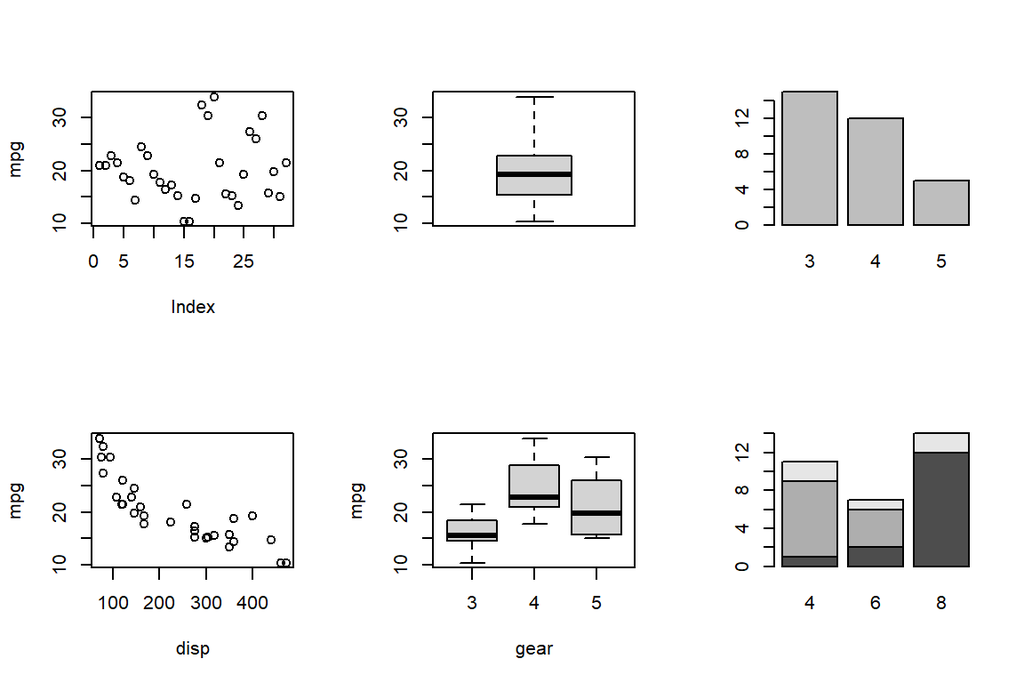

```r
par(mfrow = c(2, 3))                 # plot array with rows, 3 columns
with(mtcars, plot(mpg))              # or plot(mtcars$mpg)
with(mtcars, boxplot(mpg))
with(mtcars, plot(factor(gear)))
with(mtcars, plot(disp, mpg))
with(mtcars, boxplot(mpg ~ gear))
with(mtcars, barplot(xtabs(~ gear + cyl))) # no legend!
```

## Low-level plot functions

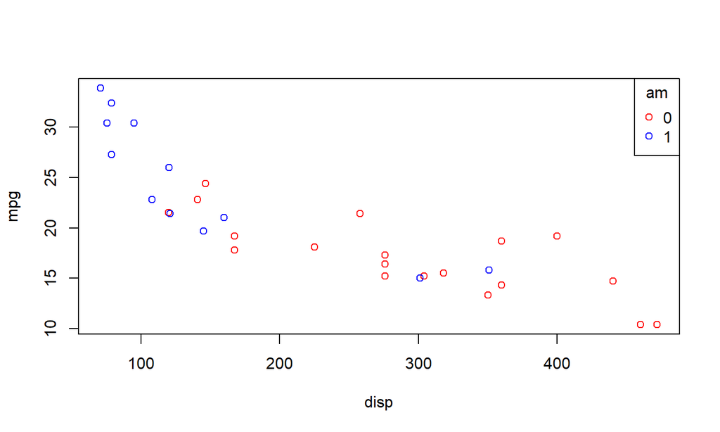

```r
with(mtcars, plot(disp, mpg, col = c("red", "blue")[am + 1]))
legend("topright", legend = c("0", "1"), col = c("red", "blue"),
       pch = 1, title =  "am")
```

## Same plot with `ggplot2`

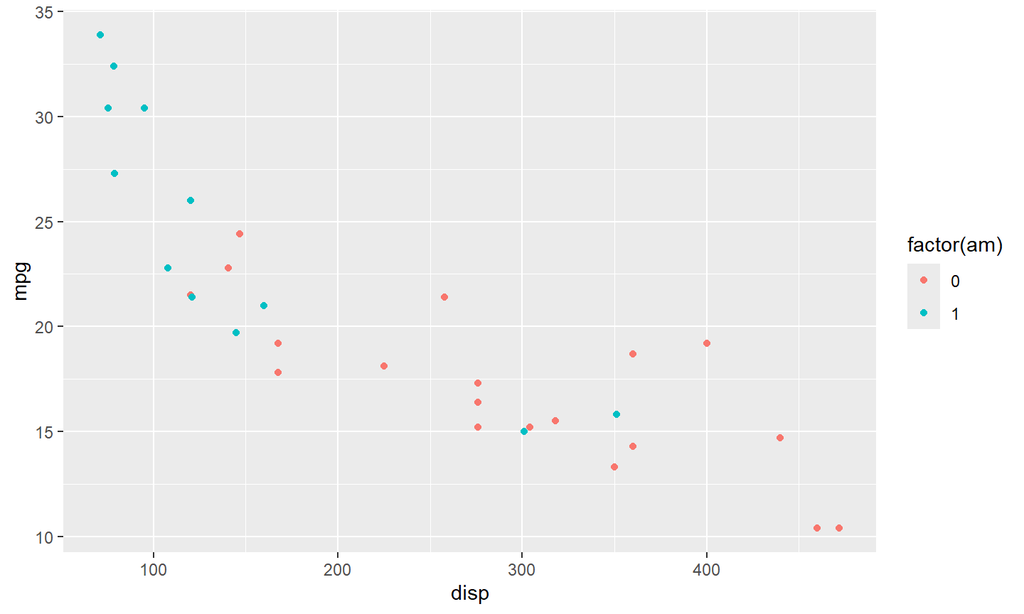

```r
ggplot(mtcars, aes(disp, mpg, col = factor(am))) +
  geom_point()
```

## ggplot2

## What is `ggplot2`?

Layered plotting based on the book **The Grammar of Graphics** by Leland Wilkinsons.

- start at the bottom and work your way up

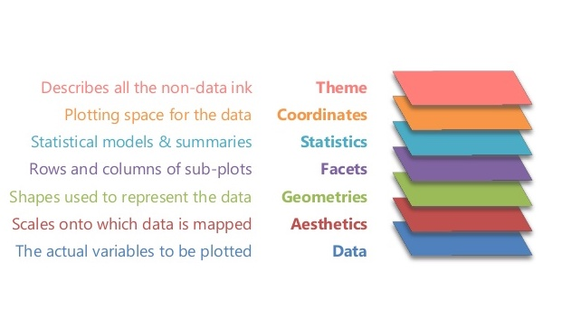

## What is `patchwork’?

Package to combine ggplots in a single array (like the base R `par(mfrow)`)

- two plots in one row

  `ggplot1 + ggplot 2`
- two plots in one column

  `ggplot1 / ggplot 2`
- Combine axis names and legends if the same

  `ggplot1 + ggplot2 + plot_layout(guides = "collect", axes = "collect")`

## Data, aesthetics and geometrics

1. Data argument (name of the data set)
2. Aesthetics (where do the variables go to)
3. Geometrics (what shapes represent the variables)

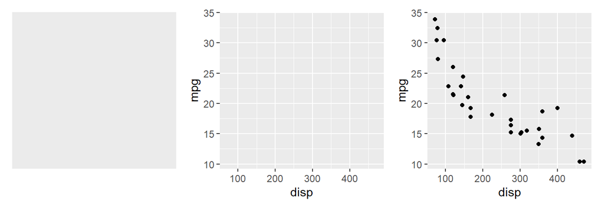

```r
library(patchwork)                           # combine plots in one figure
ggplot(data = mtcars) +                      # plot 1 = data
ggplot(mtcars, (aes(x = disp, y = mpg))) +   # plot 2 = variables to x and y
ggplot(mtcars, aes(disp, mpg)) +             # plot 3 = represent as points
  geom_point()
```

## Save a `ggplot` object

It is possible to save plot object, and add layers later

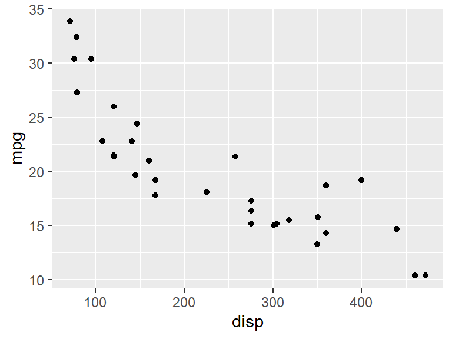

```r
gg <- ggplot(mtcars, aes(disp, mpg)) +
  geom_point()
gg
```

## Add aesthetics and geometrics

1. Add a smooth regression line
2. Add colors for `am` (transmission) and loose the confidence band
3. Display separate linear regression lines for `am`

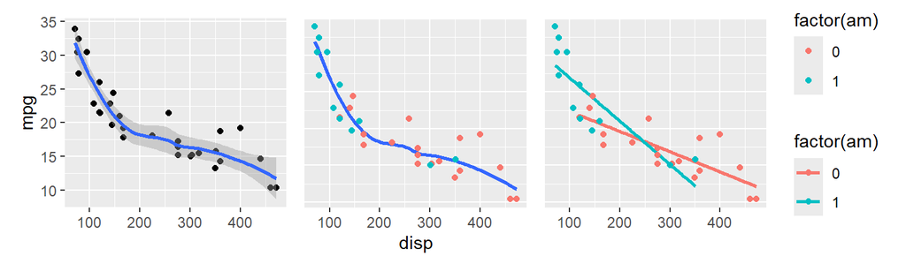

```r
gg + geom_smooth() +
gg + geom_smooth(se = F) +
  geom_point(aes(col = factor(am))) +
gg + geom_smooth(aes(col = factor(am)), method = "lm", se = F) +
  geom_point(aes(col = factor(am)))  +
  plot_layout(guides = "collect", axes = "collect")  # collect labels/legends
```

## Add title, change label/theme

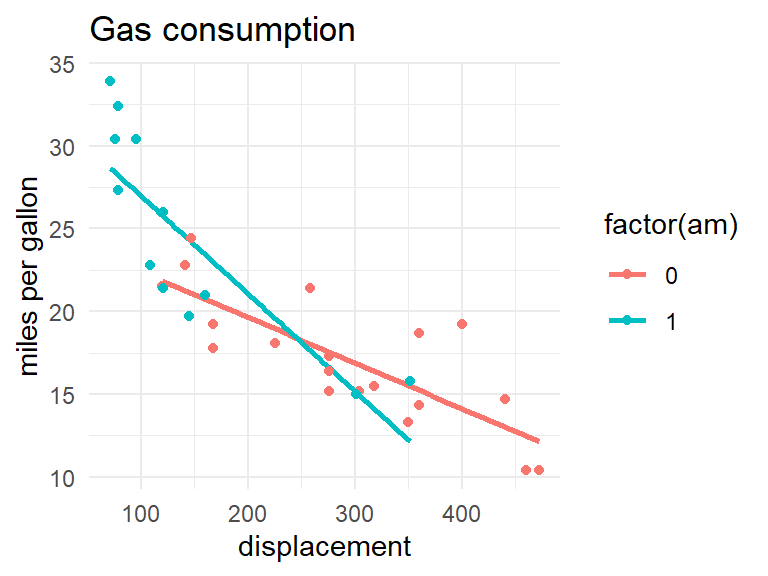

```r
gg  + geom_smooth(aes(col = factor(am)), method = "lm", se = F) +
  geom_point(aes(col = factor(am))) +
  labs(x = "displacement", y = "miles per gallon", title = "Gas consumption") +
  theme_minimal()
```

## Other aesthetics

- size
  - resize of geom according to value of a numeric variable
- color
  - color of geom on basis of a numeric/categorical variable
- fill
  - fill geom according to categories of a variable
- shape
  - change the shape of a geom according to categories of a variable
- alpha
  - change the opacity of a geom
- and others …

## Adding size

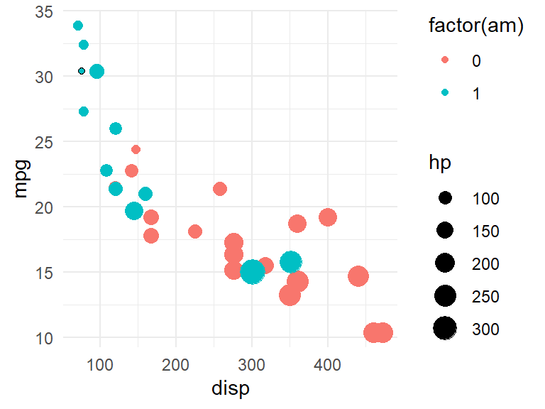

```r
gg + geom_point(aes(col = factor(am), size = hp)) +
  theme_minimal()
```

## Overview most used geoms

- geom_point
- geom_bar
- geom_line
- geom_smooth
- geom_histogram
- geom_boxplot
- geom_violin
- geom_density
- geom_bar
- and many more…

## `ggplot2` cheat sheet

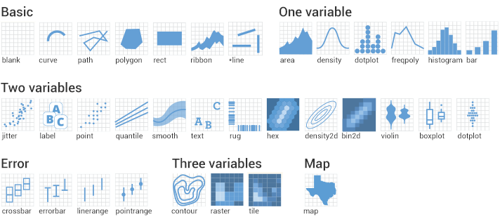

## Some examples

## Histograms and density plots

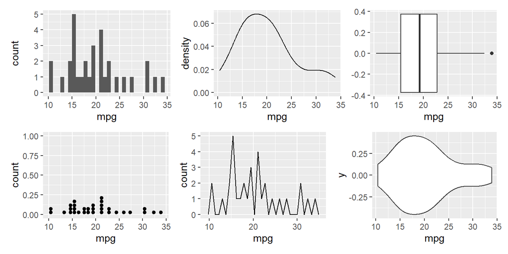

```r
p <- ggplot(mtcars, aes(x = mpg))
(p + geom_histogram() + p + geom_density() + p + geom_boxplot()) /
  (p + geom_dotplot() + p + geom_freqpoly() + p + geom_violin(aes(y=0)))
```

## Bar charts

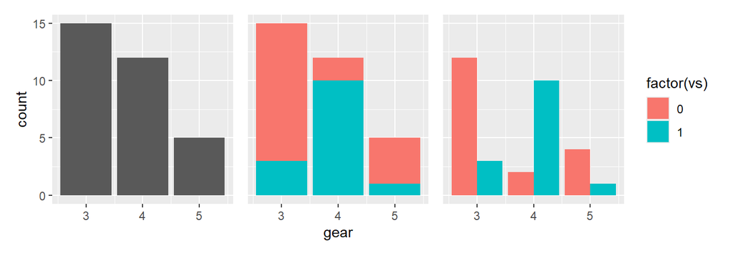

```r
ggplot(mtcars) + geom_bar(aes(gear)) +
ggplot(mtcars) + geom_bar(aes(gear, fill = factor(vs))) +
ggplot(mtcars) + geom_bar(aes(gear, fill = factor(vs)), position = "dodge") +
  ylim(0, 15) +
  plot_layout(guides = "collect", axes = "collect")
```

## Boxplots and densities

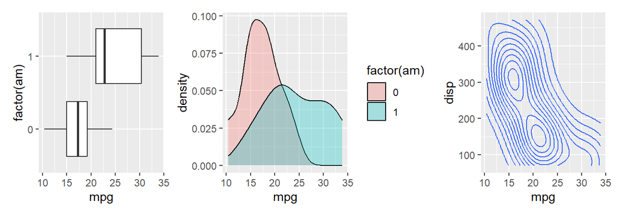

```r
ggplot(mtcars, aes(mpg, factor(am))) + geom_boxplot() +
ggplot(mtcars, aes(mpg, fill = factor(am))) + geom_density(alpha = .3) +
ggplot(mtcars, aes(mpg, disp)) + geom_density_2d()
```

## Facets

Splitting the plot by levels of a categorical variable

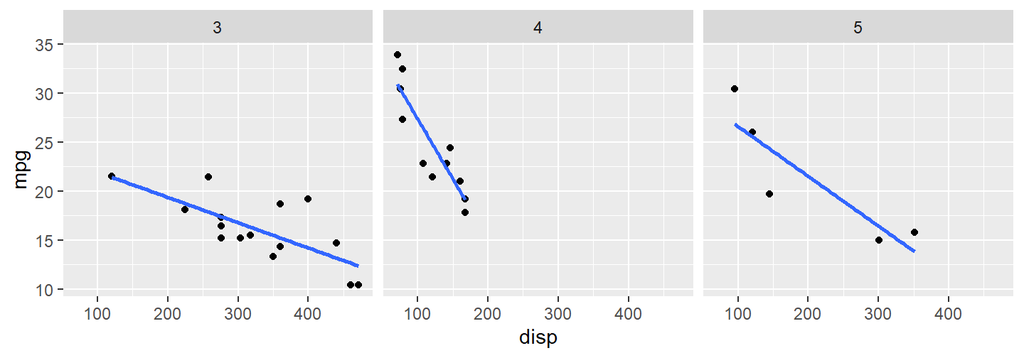

```r
gg + geom_smooth(method = "lm", se = F) +
  facet_grid(cols = vars(gear))
```

## Resizing plots

R Markdown has chunk options to resize plots. This is especially useful when more than one plot is displayed in a single plot array.

- `fig.width = 7` is the default width of the array
- `fig.height = 5` is the default height of the array
- `fig.asp = .7` is the default height:width ratio

\(~\)

The defaults can be changed as follows:

`` ```{r fig.asp = .4} ``

to reduce the height.

## Helpful link in RStudio

[figure not shown]